# Projet DM

Rochd

25 octobre 2017

# Exploration des données

## Chargement des données

Nous allons charger et fusionner les bases de données en gardant uniquement les attributs nécessaires.

Base d’apprentissage :

```r
df<-read.csv("train.csv")
df$Date<- as.POSIXct(df$Date ,format = "%Y-%m-%d")
```

Base de tests :

```r
test<-read.csv("test.csv")
```

Pour la base contenant les magasins nous allons adapter les attributs “CompetitionOpenSinceMonth” et “CompetitionOpenSinceYear”ansi que “Promo2SinceWeek” et “Promo2SinceYear” pour représenter une date précise sous le format “AAAA-MM-JJ” du calendrier POSIXct.

```r
store<-read.csv("store.csv",na.strings = "")
store$Promo2Since <- as.POSIXct(paste(store$Promo2SinceYear,store$Promo2SinceWeek, 1, sep = "-"),format = "%Y-%U-%u")
store$CompetitionOpenSince<- as.POSIXct(paste(store$CompetitionOpenSinceYear ,store$CompetitionOpenSinceMonth , 1, sep = "-"),format = "%Y-%m-%d")

#Delete redundant features
store$CompetitionOpenSinceMonth<-NULL
store$CompetitionOpenSinceYear<-NULL
store$Promo2SinceWeek<-NULL
store$Promo2SinceYear<-NULL
```

Visualisation des données manquantes :

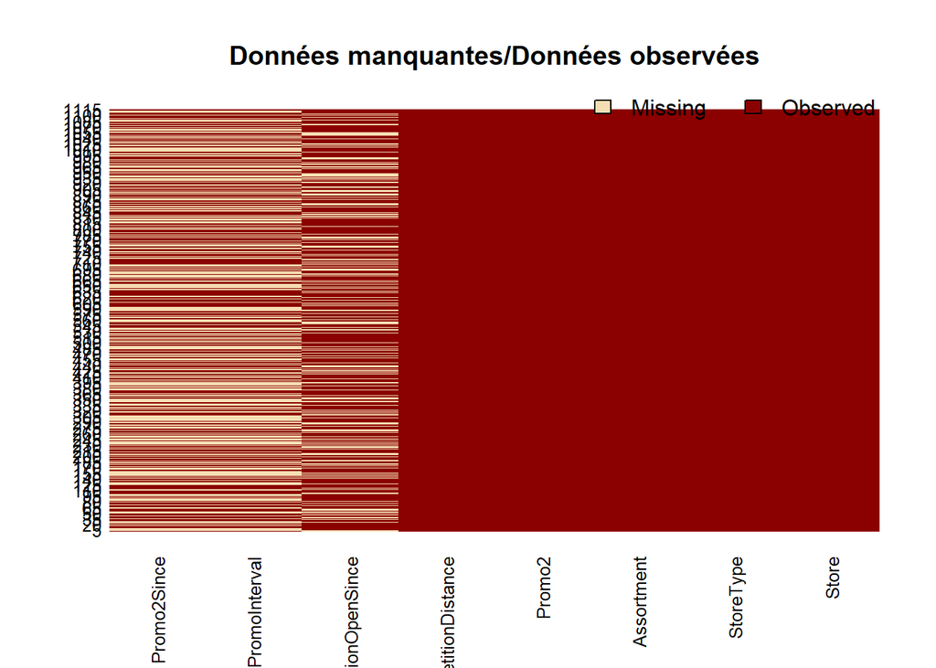

```r
library(Amelia)
missmap(store, main = "Données manquantes/Données observées")
```

```r
sapply(store,function(x) sum(is.na(x)))
```

```
##                Store            StoreType           Assortment
##                    0                    0                    0
##  CompetitionDistance               Promo2        PromoInterval
##                    3                    0                  544
##          Promo2Since CompetitionOpenSince
##                  544                  354
```

Pour les valeurs manquantes en relation avec le fait que le magasin participe à la promotion ou non ne causent aucun problème. Concernant les 3 valeurs manquantes de l’attribut “CompetitionDistance” on observe :

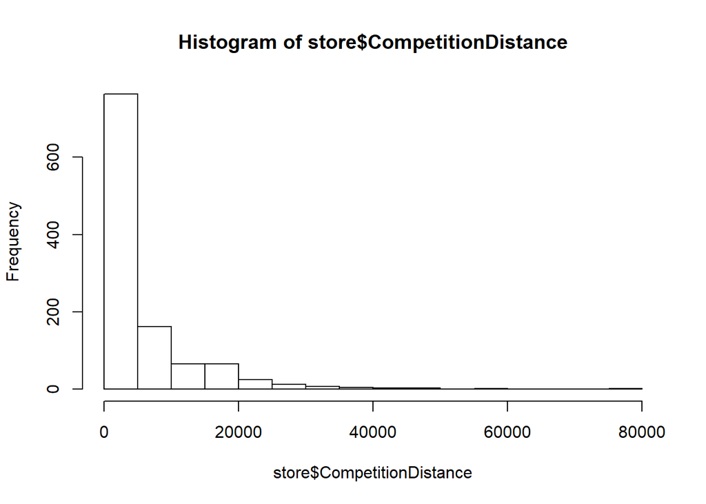

```r
hist(store$CompetitionDistance)
```

La majorité des magasins ont une distance de compétition inférieur à 5000 On choisira donc des valeurs inférieur à 5000 pour ces données manquantes.

```r
store$CompetitionDistance[is.na(store$CompetitionDistance)]<-as.integer(runif(3, 0, 5000))
```

Données manquantes de la base des tests :

```r
sapply(test,function(x) sum(is.na(x)))
```

```
##            Id         Store     DayOfWeek          Date          Open
##             0             0             0             0            11
##         Promo  StateHoliday SchoolHoliday
##             0             0             0
```

Nous allons selectionner les lignes qui correspendent à ces valeurs manquantes :

```r
test[is.na(test$Open), ]
```

```
##          Id Store DayOfWeek       Date Open Promo StateHoliday
## 480     480   622         4 2015-09-17   NA     1            0
## 1336   1336   622         3 2015-09-16   NA     1            0
## 2192   2192   622         2 2015-09-15   NA     1            0
## 3048   3048   622         1 2015-09-14   NA     1            0
## 4760   4760   622         6 2015-09-12   NA     0            0
## 5616   5616   622         5 2015-09-11   NA     0            0
## 6472   6472   622         4 2015-09-10   NA     0            0
## 7328   7328   622         3 2015-09-09   NA     0            0
## 8184   8184   622         2 2015-09-08   NA     0            0
## 9040   9040   622         1 2015-09-07   NA     0            0
## 10752 10752   622         6 2015-09-05   NA     0            0
##       SchoolHoliday
## 480               0
## 1336              0
## 2192              0
## 3048              0
## 4760              0
## 5616              0
## 6472              0
## 7328              0
## 8184              0
## 9040              0
## 10752             0
```

Ceci correspond uniquement au magasin numéro 622 :

```r
table(test$Open[test$Store == 622])
```

```
##
##  0  1
##  7 30
```

Dans la majorité des cas le magasin est ouvert : Nous allons donc affecter des “1” aux valeurs manquantes :

```r
test[is.na(test)] <- 1
```

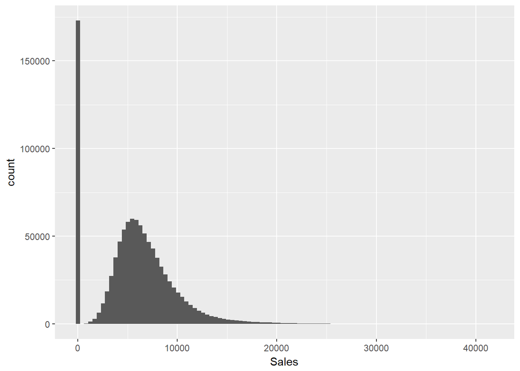

```r
library(ggplot2)
ggplot(df, aes(Sales))+geom_histogram(bins = 100)
```

```r
train <-merge(df,store)

#which(mergedData$Date<mergedData$Promo2Since)
Inferieur=train[which(train$Date<train$Promo2Since & train$Store==213),]
mean(Inferieur$Sales)
```

```
## [1] 6093.576
```

```r
superieur=train[which(train$Date>=train$Promo2Since & train$Store==213),]
mean(superieur$Sales)
```

```
## [1] 7131.92
```